# `ridgetorus`: PCA on the Torus via Density Ridges

Eduardo García-Portugués and Arturo Prieto-Tirado

2023-08-27, v1.0.2

In a wide spectrum of applied fields, data is present as multivariate circular data (toroidal data), rendering spurious the application of many standard statistical tools. The package `ridgetorus` implements Toroidal Ridge PCA (TR-PCA), an alternative to PCA suited to toroidal data (García-Portugués and Prieto-Tirado 2023). Below are some simple examples of the use of TR-PCA through `ridge_pca()`, the main function in `ridgetorus`.

## Texan wind

The following example illustrates the application of TR-PCA to a small dataset comprised by wind directions measured at 6:00 and 7:00 from June 1, 2003 to June 30, 2003 at a weather station in Texas. The direction is measured in radians in $[-\pi, \pi)$ with $-\pi/-\frac{\pi}{2}/0/\frac{\pi}{2}/\pi$ representing the East/South/West/North/East directions.

```r
library(ridgetorus)
```

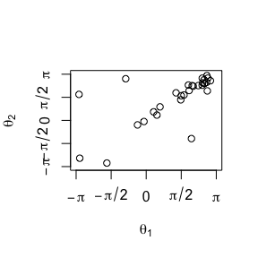

```r
data("wind")
plot(wind, xlim = c(-pi, pi), ylim = c(-pi, pi), axes = FALSE,
     xlab = expression(theta[1]), ylab = expression(theta[2]))
sdetorus::torusAxis()
```

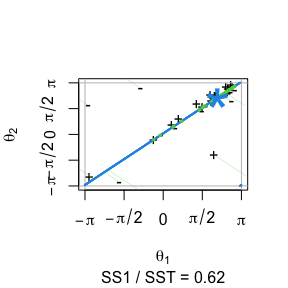

```r
# Fit TR-PCA
fit <- ridge_pca(x = wind)
show_ridge_pca(fit)
```

```r
# Variance explained
fit$var_exp
```

```
#> [1] 0.6191477 1.0000000
```

The produced scores allow the identification of outliers and “rectify” the original sample.

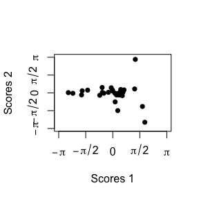

```r
plot(fit$scores, xlim = c(-pi, pi), ylim = c(-pi, pi), pch = 16, axes = FALSE,
     xlab = "Scores 1", ylab = "Scores 2")
sdetorus::torusAxis()
```

## Japanese earthquakes

The following dataset represents pre-earthquake direction of steepest descent and the direction of lateral ground movement after an earthquake in Noshiro, Japan. We use TR-PCA to unveil the behavior and explain the variability of the earthquake phenomena.

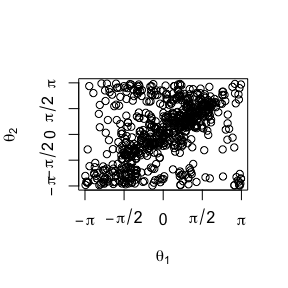

```r
data("earthquakes")
earthquakes <- sdetorus::toPiInt(earthquakes)
plot(earthquakes, xlim = c(-pi, pi), ylim = c(-pi, pi),
     xlab = expression(theta[1]), ylab = expression(theta[2]), axes = FALSE)
sdetorus::torusAxis()
```

The dataset is modeled with the best-fitting model among a Bivariate Wrapped Cauchy and a Bivariate Sine von Mises. Once the distribution is determined, the connected component of the density ridge can be computed. This flexible first principal component explains $66\%$ of the variance and shows a clear linear trend between both studied angles.

```r
fit_earthquakes <- ridge_pca(x = earthquakes)
fit_earthquakes$var_exp
```

```
#> [1] 0.6554334 1.0000000
```

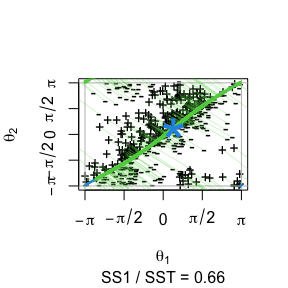

```r
show_ridge_pca(fit_earthquakes)
```

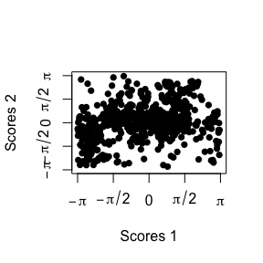

```r
plot(fit_earthquakes$scores, pch = 16, xlim = c(-pi, pi), axes = FALSE,
     ylim = c(-pi, pi), xlab = "Scores 1", ylab = "Scores 2")
sdetorus::torusAxis()
```

## References

García-Portugués, E., and A. Prieto-Tirado. 2023. “Toroidal PCA via Density Ridges.” *Stat. Comput.* 33 (5): 107. https://doi.org/10.1007/s11222-023-10273-9.

Genovese, C. R., M. Perone-Pacifico, I. Verdinelli, and L. Wasserman. 2014. “Nonparametric Ridge Estimation.” *The Annals of Statistics* 42 (4): 1511–45. https://doi.org/10.1214/14-AOS1218.

Kato, S., and A. Pewsey. 2015. “A Möbius Transformation-Induced Distribution on the Torus.” *Biometrika* 102 (2): 359–70. https://doi.org/10.1093/biomet/asv003.

Singh, H., V. Hnizdo, and E. Demchuk. 2002. “Probabilistic Model for Two Dependent Circular Variables.” *Biometrika* 89 (3): 719–23. https://doi.org/10.1093/biomet/89.3.719.